# Analysing Data Coursework Report

*N* removed NAs: 3

*N* removed typo: 1

*N* removed <18: 27

*N* total clean: 119

| Group | *N* | *M*<sub>age</sub> | *M*<sub>rating</sub> |
| --- | --- | --- | --- |
| Control | 55 | 20.8 | 6.41 |
| Experim | 64 | 21.4 | 5.51 |

**Main analysis results**

*t*(117) = 5.95, *p* < .001

[interactive chart not shown]

[figure not shown]

[interactive chart not shown]

# Analysing Data Coursework Report

Analysing Data, Spring 2020 - Candidate Number 219244

# **Methods**

## **Participants**

*Figure 1: A Table showing the Ages and Ages Ranges of Participants in the study*

| N | M<sub>Age</sub> | SD | Maximum | Minimum | Range |
| --- | --- | --- | --- | --- | --- |
| 137 | 20.6 | 2.42 | 27 | 16 | 11 |

*Figure 2: A Table showing the Ages and Ages Ranges of Participants in the study in relation to Experimental Condition*

| Experimental Condition | N | M<sub>Age</sub> | SD | Maximum | Minimum | Range |
| --- | --- | --- | --- | --- | --- | --- |
| Control | 63 | 20.3 | 2.32 | 26 | 16 | 10 |
| Experimental | 74 | 20.8 | 2.49 | 27 | 16 | 11 |

## **Design**

# **Results**

*Figure 3: A Table showing the effect of the colour red on perceived attractiveness*

| Group | Mean Score | Standard Deviation | Minimum Score | Maximum Score | Range |
| --- | --- | --- | --- | --- | --- |
| Control | 6.39 | 0.75 | 4.67 | 7.67 | 3.00 |
| Experimental | 5.57 | 0.84 | 3.67 | 8.00 | 4.33 |

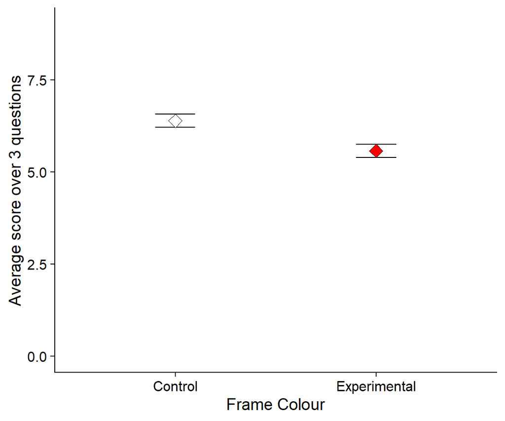

*Figure 4: A Graph showing the effect of the colour red on perceived attractiveness*

# **Discussion**

This study is a replication of the first experiment in Elliot et al’s (2010) study of experiments, with a different set of participants. It was ‘as close of a replication’ as we could produce, by the fact that we used the same photo of the man that the original experiment used (same picture, size and material), we also defined perceived attractiveness in the same way as we used the original 3 questions, in addition we also used the exact same 9-point scale for answering the questions. However, our results did not show and increased perceived attractiveness when the picture had a red background, which Elliot et al’s original experiment did (as they showed having the picture on a red background on average increased the perceived attractiveness by 1.12 points). In fact, our results seem to suggest the opposite with participants who saw the man on a white background rating perceiving him as more attractive. The most likely reason for the opposite result in our experiment compared to the original is because we used a mixed gender sample in our data set, whereas Elliot et al only used females. So, it may be that we didn’t see the increase in perceived attractiveness for the red group because we used males in my sample who may have rated attractiveness differently based on the colour of the background.

To discover if this effect truly does exist, we can also look at other studies into this area, for example Hesslinger, Goldback and Carbon (2015) also conducted a study in this field. They too also repeated Elliot et al’s original experiment, however like their study, they used a mixed gender sample, but still found an increase in perceived attractiveness for participants seeing the man on a red background, but only a small difference (“condition *red*: *M* = 5.71, *SD* = 1.70; condition *white*: *M* = 5.39, *SD* = 1.53”). However, this replication did not yield a statistically significant effect, suggesting that this effect may not be as strong as originally suggested by Elliot et al in their study. However, this result may have been due to the fact that a mixed gender sample was used so we can look at a study that uses just one gender, for example Leonard et al (2016). They used 443 men (*Mean Age* = 29.71 years, *SD* = 9.40 years, *Range* = 16-72 years) for the study, which was a very large sample, who saw a picture of a female wearing either a white (*n* = 218) or red (*n* = 215) dress for 5 seconds, which was followed by a questionnaire. The questionnaire was used to rate the perceived attraction towards the woman in the picture using 4 questions (“how sexy is the person acting?”, “how seductive is this person?”, “how flirtatious is this person?” and “this person interested in sex”) to create a 1 to 9 point scale (from 1 being not at all attractive and 9 being extremely attractive). Although, similar to our experiment and Hesslinger et al (2015) study, they found that participants who saw the woman in the red dress did not rate the woman as more attractive (“*M* = 3.57, *SD* = 1.82” for the red condition and “*M* = 3.79, *SD* = 1.81” for the white condition). Even after eliminating participants who mentioned colour when they were asked what they believe the purpose of the experiment was, the results were not change. Both these 2 studies and the evidence from my own research seem to suggest that this effect, that the colour red can increase a woman perception of a man status and subsequently her attraction towards him, simply does not exist or may not be as powerful as Elliot et al (2010) suggest in their paper.

Yet, there may be simple reason as to why I, and other researchers, were unable to replicate these findings due to limitations in the studies. For example, Elliot et al (2010) only suggest this effect applies to females, whereas both my study and Hesslinger et al (2015) use a mixed sample of genders and Leonard et al (2016) only use males. So, it may be that due to this study using both males and females to study this phenomenon we did not get significant support that it exists, but we may have if the participants only consisted of females (or people who attracted to females). Another limitation of this experiment was that participants only looked at 1 picture of 1 male on different background. It may have been more beneficial to have multiple different pictures of different men and examine whether we can get this effect for men of different background, ethnic groups and nationalities as currently we are just limited to looking at the perceived attractiveness of one person. On the other hand, it is important to note that this study has a strong ecological validity, particularly at this period of time (2020). As more and more dating sites are turning to online platforms most relationships can begin by just looking at a picture of the person, as this is usually ‘Step 1’ to beginning the relationship. So, this study does have strong applications to real-life as people using dating sites will judge attractiveness from typically a single picture.

As a result, despite this evidence not supporting Elliot et al (2010) original hypothesis that this study is based off, I do believe that this research question is worth investigating further. Firstly, as most the research done is just one the background, which face to face can be very hard to change, so it would be interesting if changing things such as your clothes or hair colour to red also increases perceived attractiveness. Although, as this current generation is becoming more prone to using online forms of dating to form relationships, which presently use predominately pictures, this could become a popular subject of interest as more people may look for physical features to make them seem more attractive. Particularly, during the current global pandemic with many people currently being confined to their homes and social distancing liking being in effect for a lengthy period of time, most people will likely be using online platforms for dating. As a consequence, for this most people will be judging attractiveness on a single picture, so by doing research into this area we could help people seem more attractive by changing simple things such as the colour of their clothes.

In summary, the results of this experiment did not support the ‘red effect’ that was reported by Elliot et al (2010), which suggests that the colour red can increase a woman’s perception of a man’s status, and thereby enhance her attraction towards them. Also, other studies into this research area have also been unable to come to the same conclusion Elliot et al (2010) did, though this could be partly due to the type of participants used in follow-up experiments, and this effect was originally only reported to work on females seeing males as more attractive. However, I do believe it is important to conduct more research into this area as particularly during this current period of time (2020) more and more people like base attractiveness, and most likely whether they want to form a relationship with that person, based on a single image.

# **References**

Elliot, A. J., Niesta Kayser, D. & Greitemeyer, T., Lichtenfeld, S., Gramzow, R. H., Maier, M. A., & Liu, H. (2010). Red, rank, and romance in women viewing men. *Journal of Experimental Psychology: General, 139*(3), 399.

Hesslinger, V. M., Goldback, L., Carbon, C. (2015). A reexamination of the red-attractiveness effect. *Psychon Bull Rev. *22** 1142-1148 (2015).

Leonard, S., Peperkoorn, S., Roberts, C. & Pollet, V. (2016). Revisiting the Red Effect on Attractiveness and Sexual Receptivity: No Effect of the Colour Red on Human Mate Preferences. *Evolutionary Psychology*.